# limiares

#### Allegro

0.1 [1] “

"

#### Evolução dos desenvolvedores ao longo do tempo (Desktop Mobile)

( janela 24 semanas, iteracao de 4 semanas) [1] “

"

|  | mobile | desktop | mobiledesktop |
| --- | --- | --- | --- |
| twosided | 0.4862343 | 0.0032598 | 0.0000003 |
| greater | 0.7568828 | 0.0016299 | 0.9999999 |
| less | 0.2431172 | 0.9983701 | 0.0000001 |

#### Allegro

0.2 [1] “

"

#### Evolução dos desenvolvedores ao longo do tempo (Desktop Mobile)

( janela 24 semanas, iteracao de 4 semanas) [1] “

"

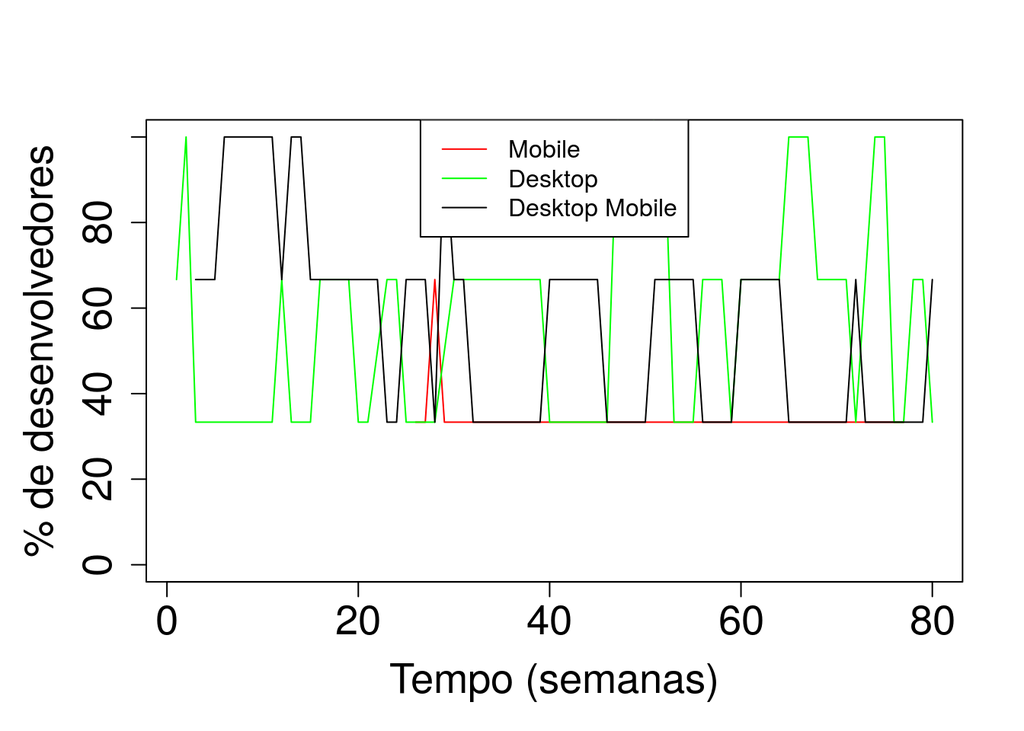

|  | mobile | desktop | mobiledesktop |
| --- | --- | --- | --- |
| twosided | 0.4862343 | 0.0032598 | 0.0000003 |
| greater | 0.7568828 | 0.0016299 | 0.9999999 |
| less | 0.2431172 | 0.9983701 | 0.0000001 |

#### Allegro

0.3 [1] “

"

#### Evolução dos desenvolvedores ao longo do tempo (Desktop Mobile)

( janela 24 semanas, iteracao de 4 semanas) [1] “

"

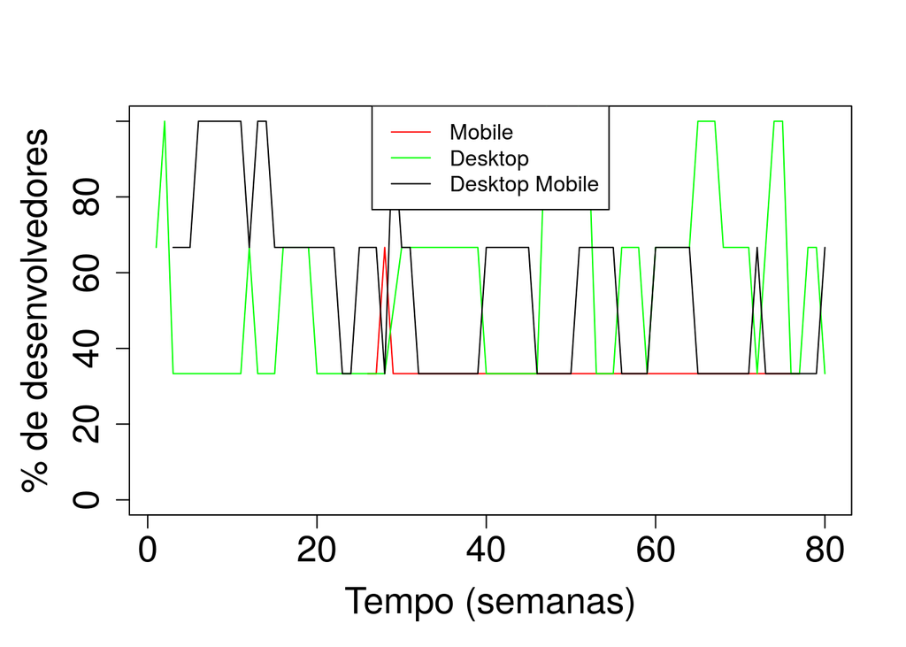

|  | mobile | desktop | mobiledesktop |
| --- | --- | --- | --- |
| twosided | 0.4862343 | 0.0031619 | 0.0000003 |
| greater | 0.7568828 | 0.0015809 | 0.9999999 |
| less | 0.2431172 | 0.9984191 | 0.0000001 |

#### Allegro

0.4 [1] “

"

#### Evolução dos desenvolvedores ao longo do tempo (Desktop Mobile)

( janela 24 semanas, iteracao de 4 semanas) [1] “

"

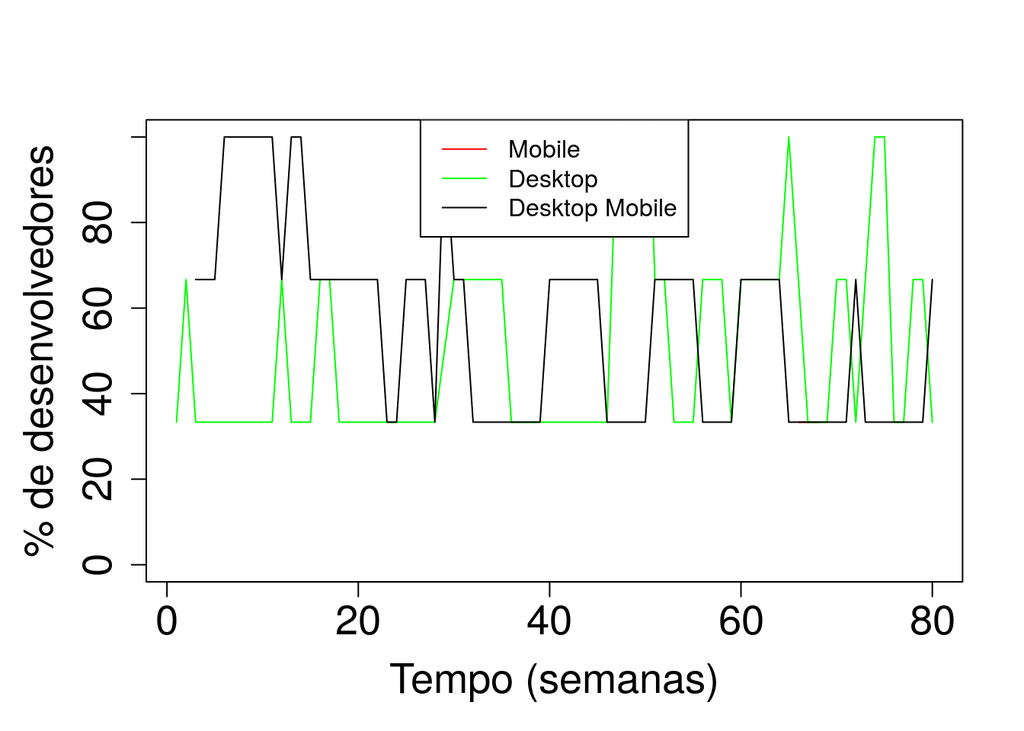

|  | mobile | desktop | mobiledesktop |
| --- | --- | --- | --- |
| twosided | NaN | 0.0032577 | 0.0000003 |
| greater | NaN | 0.0016289 | 0.9999999 |
| less | NaN | 0.9983711 | 0.0000001 |

#### Allegro

0.5 [1] “

"

#### Evolução dos desenvolvedores ao longo do tempo (Desktop Mobile)

( janela 24 semanas, iteracao de 4 semanas) [1] “

"

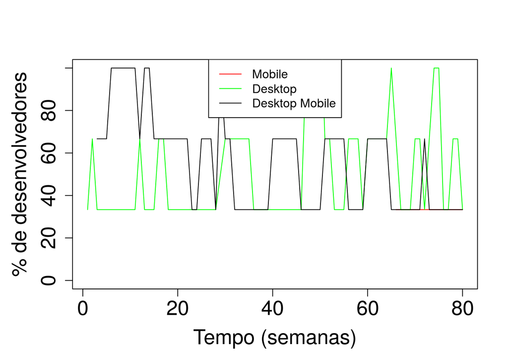

|  | mobile | desktop | mobiledesktop |
| --- | --- | --- | --- |
| twosided | NaN | 0.0032577 | 0.0000003 |
| greater | NaN | 0.0016289 | 0.9999998 |
| less | NaN | 0.9983711 | 0.0000002 |

#### SDL

0.1 [1] “

"

#### Evolução dos desenvolvedores ao longo do tempo (Desktop Mobile)

( janela 24 semanas, iteracao de 4 semanas) [1] “

"

|  | mobile | desktop | mobiledesktop |
| --- | --- | --- | --- |
| twosided | 0.5830637 | 0.0001255 | 0.016656 |
| greater | 0.2915319 | 0.0000627 | 0.008328 |
| less | 0.7084681 | 0.9999373 | 0.991672 |

#### SDL

0.2 [1] “

"

#### Evolução dos desenvolvedores ao longo do tempo (Desktop Mobile)

( janela 24 semanas, iteracao de 4 semanas) [1] “

"

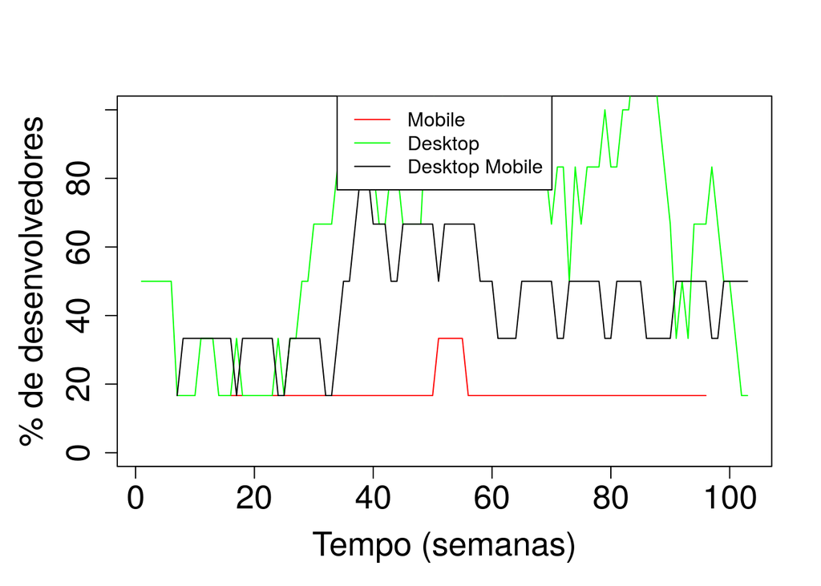

|  | mobile | desktop | mobiledesktop |
| --- | --- | --- | --- |
| twosided | 0.5830637 | 0.0001255 | 0.016656 |
| greater | 0.2915319 | 0.0000627 | 0.008328 |
| less | 0.7084681 | 0.9999373 | 0.991672 |

#### SDL

0.3 [1] “

"

#### Evolução dos desenvolvedores ao longo do tempo (Desktop Mobile)

( janela 24 semanas, iteracao de 4 semanas) [1] “

"

|  | mobile | desktop | mobiledesktop |
| --- | --- | --- | --- |
| twosided | 0.5830637 | 0.0001255 | 0.016656 |
| greater | 0.2915319 | 0.0000627 | 0.008328 |
| less | 0.7084681 | 0.9999373 | 0.991672 |

#### SDL

0.4 [1] “

"

#### Evolução dos desenvolvedores ao longo do tempo (Desktop Mobile)

( janela 24 semanas, iteracao de 4 semanas) [1] “

"

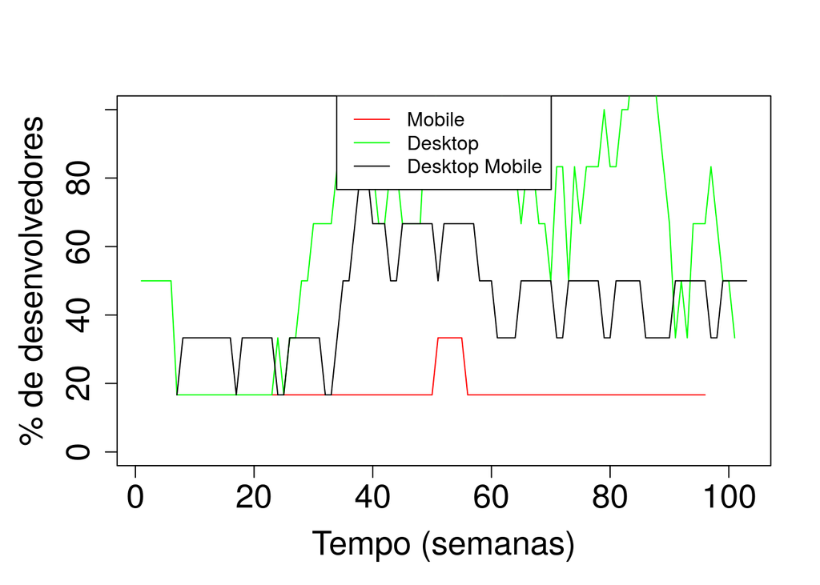

|  | mobile | desktop | mobiledesktop |
| --- | --- | --- | --- |
| twosided | 0.5830637 | 0.0000646 | 0.016656 |
| greater | 0.2915319 | 0.0000323 | 0.008328 |
| less | 0.7084681 | 0.9999677 | 0.991672 |

#### SDL

0.5 [1] “

"

#### Evolução dos desenvolvedores ao longo do tempo (Desktop Mobile)

( janela 24 semanas, iteracao de 4 semanas) [1] “

"

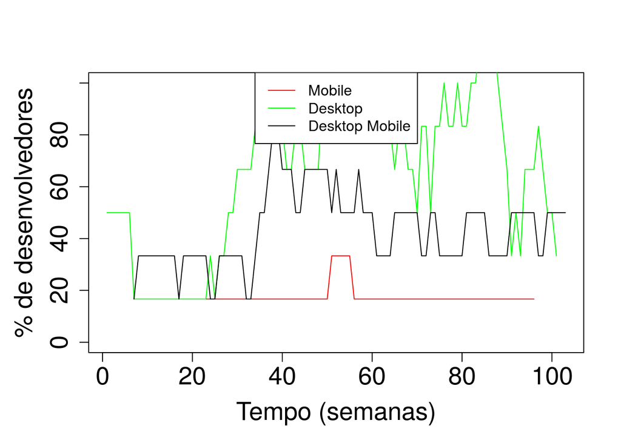

|  | mobile | desktop | mobiledesktop |
| --- | --- | --- | --- |
| twosided | 0.5830637 | 0.0000486 | 0.0200961 |
| greater | 0.2915319 | 0.0000243 | 0.0100480 |
| less | 0.7084681 | 0.9999757 | 0.9899520 |

#### SFML

0.1 [1] “

"

#### Evolução dos desenvolvedores ao longo do tempo (Desktop Mobile)

( janela 24 semanas, iteracao de 4 semanas) [1] “

"

|  | mobile | desktop | mobiledesktop |
| --- | --- | --- | --- |
| twosided | NaN | 0.0013022 | 0.3247916 |
| greater | NaN | 0.9993489 | 0.8376042 |
| less | NaN | 0.0006511 | 0.1623958 |

#### SFML

0.2 [1] “

"

#### Evolução dos desenvolvedores ao longo do tempo (Desktop Mobile)

( janela 24 semanas, iteracao de 4 semanas) [1] “

"

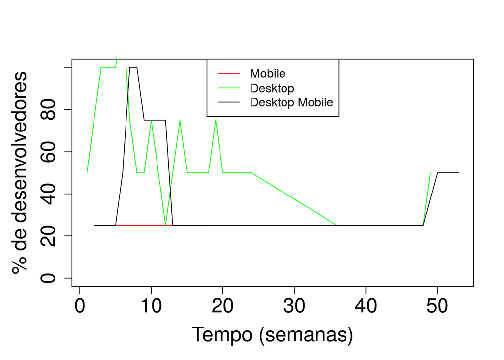

|  | mobile | desktop | mobiledesktop |
| --- | --- | --- | --- |
| twosided | NaN | 0.0013022 | 0.3247916 |
| greater | NaN | 0.9993489 | 0.8376042 |
| less | NaN | 0.0006511 | 0.1623958 |

#### SFML

0.3 [1] “

"

#### Evolução dos desenvolvedores ao longo do tempo (Desktop Mobile)

( janela 24 semanas, iteracao de 4 semanas) [1] “

"

|  | mobile | desktop | mobiledesktop |
| --- | --- | --- | --- |
| twosided | NaN | 0.0013022 | 0.3247916 |
| greater | NaN | 0.9993489 | 0.8376042 |
| less | NaN | 0.0006511 | 0.1623958 |

#### SFML

0.4 [1] “

"

#### Evolução dos desenvolvedores ao longo do tempo (Desktop Mobile)

( janela 24 semanas, iteracao de 4 semanas) [1] “

"

|  | mobile | desktop | mobiledesktop |
| --- | --- | --- | --- |
| twosided | NaN | 0.0013022 | 0.3247916 |
| greater | NaN | 0.9993489 | 0.8376042 |
| less | NaN | 0.0006511 | 0.1623958 |

#### SFML

0.5 [1] “

"

#### Evolução dos desenvolvedores ao longo do tempo (Desktop Mobile)

( janela 24 semanas, iteracao de 4 semanas) [1] “

"

|  | mobile | desktop | mobiledesktop |
| --- | --- | --- | --- |
| twosided | NaN | 0.0013022 | 0.3247916 |
| greater | NaN | 0.9993489 | 0.8376042 |
| less | NaN | 0.0006511 | 0.1623958 |

#### Coco2dx

0.1 [1] “

"

#### Evolução dos desenvolvedores ao longo do tempo (Desktop Mobile)

( janela 24 semanas, iteracao de 4 semanas) [1] “

"

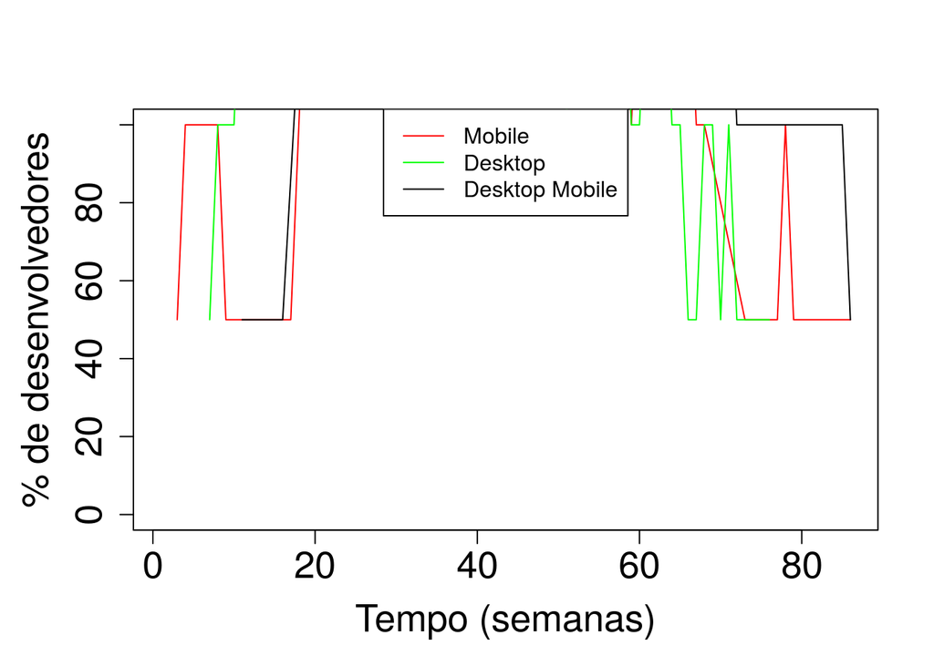

|  | mobile | desktop | mobiledesktop |
| --- | --- | --- | --- |
| twosided | 0.7031626 | 0 | 0.0000049 |
| greater | 0.6484187 | 1 | 0.9999975 |
| less | 0.3515813 | 0 | 0.0000025 |

#### Coco2dx

0.2 [1] “

"

#### Evolução dos desenvolvedores ao longo do tempo (Desktop Mobile)

( janela 24 semanas, iteracao de 4 semanas) [1] “

"

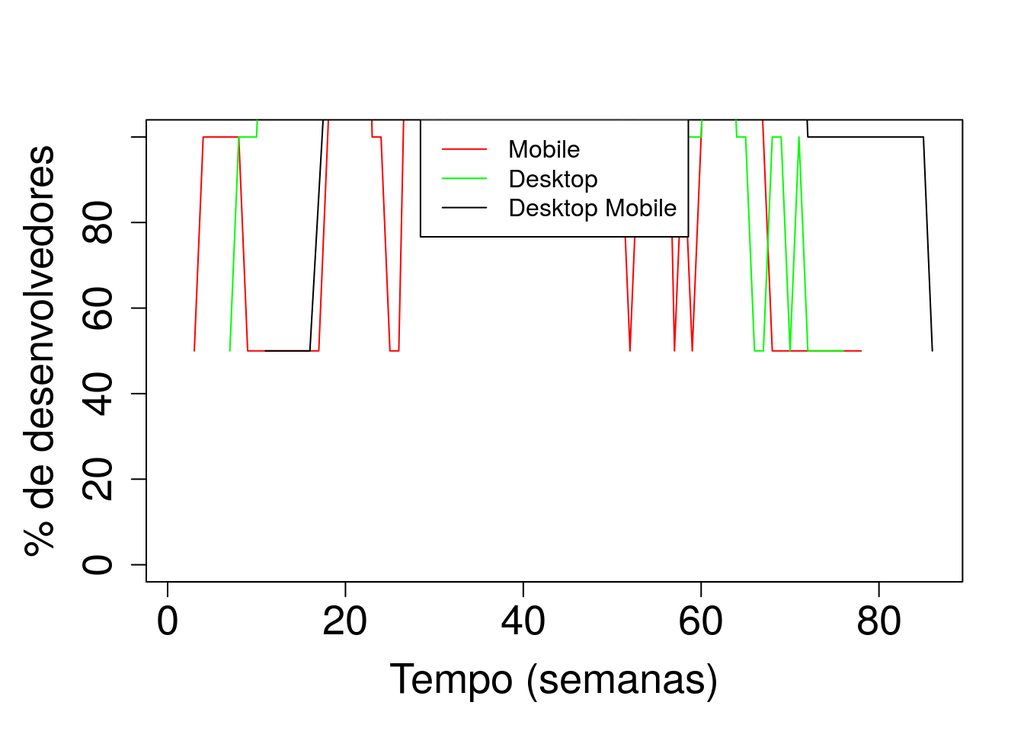

|  | mobile | desktop | mobiledesktop |
| --- | --- | --- | --- |
| twosided | 0.7753925 | 0 | 0.0000049 |
| greater | 0.3876962 | 1 | 0.9999975 |
| less | 0.6123038 | 0 | 0.0000025 |

#### Coco2dx

0.3 [1] “

"

#### Evolução dos desenvolvedores ao longo do tempo (Desktop Mobile)

( janela 24 semanas, iteracao de 4 semanas) [1] “

"

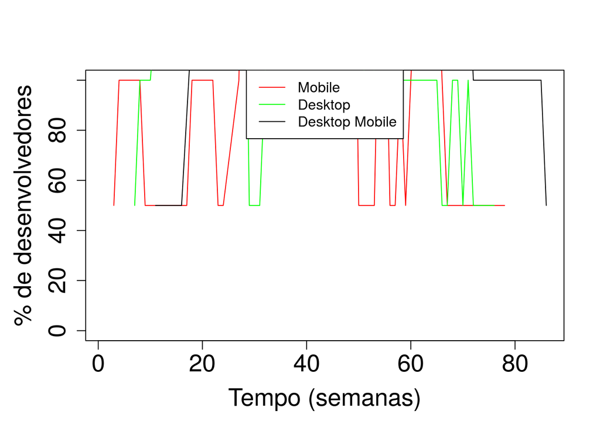

|  | mobile | desktop | mobiledesktop |
| --- | --- | --- | --- |
| twosided | 0.8862498 | 0.0000007 | 0.0000049 |
| greater | 0.5568751 | 0.9999997 | 0.9999975 |
| less | 0.4431249 | 0.0000003 | 0.0000025 |

#### Coco2dx

0.4 [1] “

"

#### Evolução dos desenvolvedores ao longo do tempo (Desktop Mobile)

( janela 24 semanas, iteracao de 4 semanas) [1] “

"

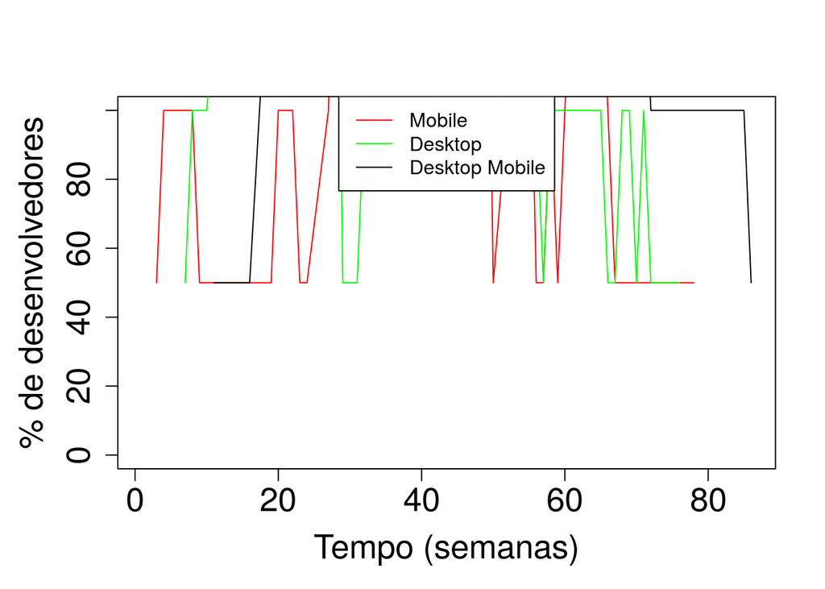

|  | mobile | desktop | mobiledesktop |
| --- | --- | --- | --- |
| twosided | 0.9711787 | 0.0000003 | 0.0000049 |
| greater | 0.4855894 | 0.9999999 | 0.9999975 |
| less | 0.5144106 | 0.0000001 | 0.0000025 |

#### Coco2dx

0.5 [1] “

"

#### Evolução dos desenvolvedores ao longo do tempo (Desktop Mobile)

( janela 24 semanas, iteracao de 4 semanas) [1] “

"

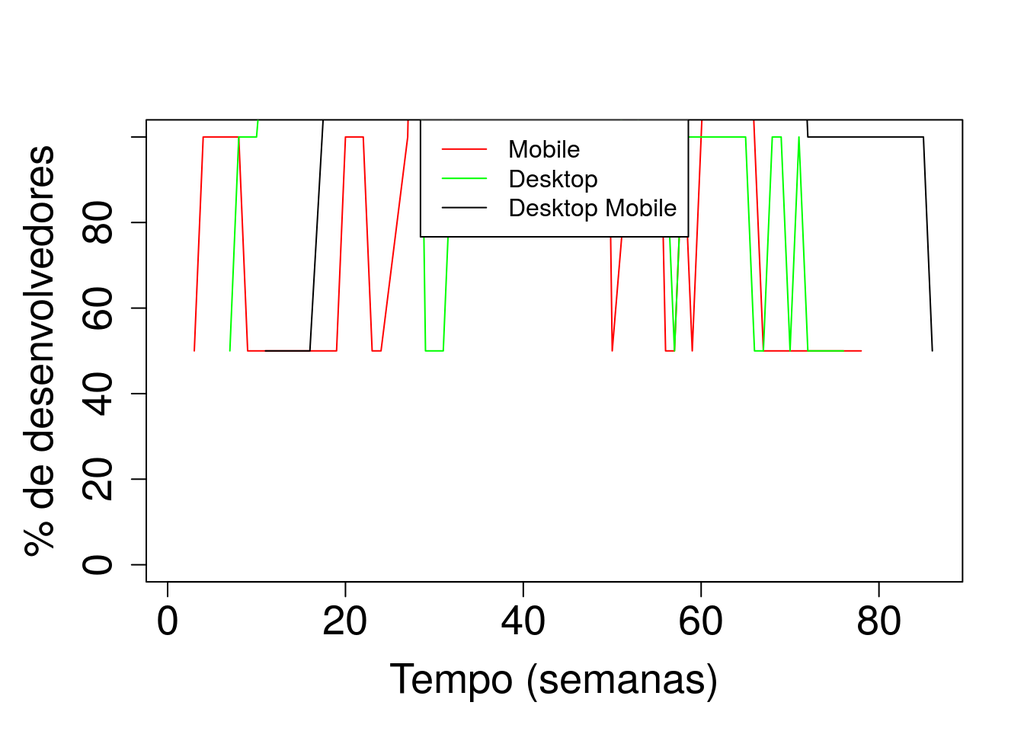

|  | mobile | desktop | mobiledesktop |
| --- | --- | --- | --- |
| twosided | 0.9711787 | 0.0000002 | 0.0000048 |
| greater | 0.4855894 | 0.9999999 | 0.9999976 |
| less | 0.5144106 | 0.0000001 | 0.0000024 |

#### Godot

0.1 [1] “

"

#### Evolução dos desenvolvedores ao longo do tempo (Desktop Mobile)

( janela 24 semanas, iteracao de 4 semanas) [1] “

"

|  | mobile | desktop | mobiledesktop |
| --- | --- | --- | --- |
| twosided | 0.0000010 | 0 | 0 |
| greater | 0.0000005 | 0 | 0 |
| less | 0.9999995 | 1 | 1 |

#### Godot

0.2 [1] “

"

#### Evolução dos desenvolvedores ao longo do tempo (Desktop Mobile)

( janela 24 semanas, iteracao de 4 semanas) [1] “

"

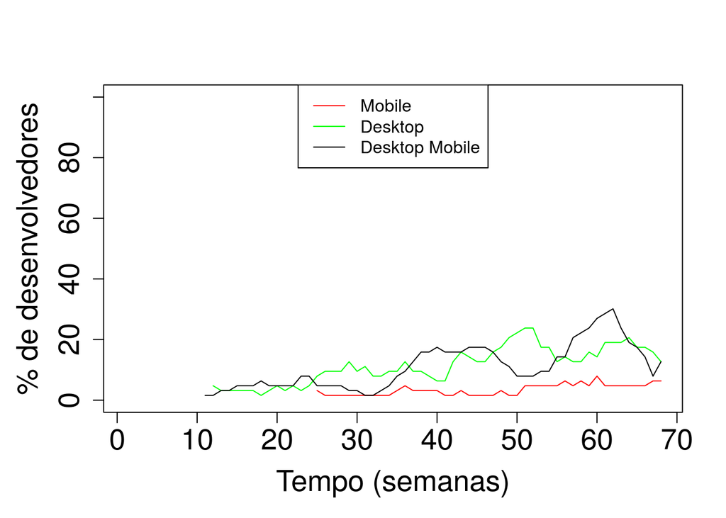

|  | mobile | desktop | mobiledesktop |
| --- | --- | --- | --- |
| twosided | 0.0000010 | 0 | 0 |
| greater | 0.0000005 | 0 | 0 |
| less | 0.9999995 | 1 | 1 |

#### Godot

0.3 [1] “

"

#### Evolução dos desenvolvedores ao longo do tempo (Desktop Mobile)

( janela 24 semanas, iteracao de 4 semanas) [1] “

"

|  | mobile | desktop | mobiledesktop |
| --- | --- | --- | --- |
| twosided | 0.0000010 | 0 | 0 |
| greater | 0.0000005 | 0 | 0 |
| less | 0.9999995 | 1 | 1 |

#### Godot

0.4 [1] “

"

#### Evolução dos desenvolvedores ao longo do tempo (Desktop Mobile)

( janela 24 semanas, iteracao de 4 semanas) [1] “

"

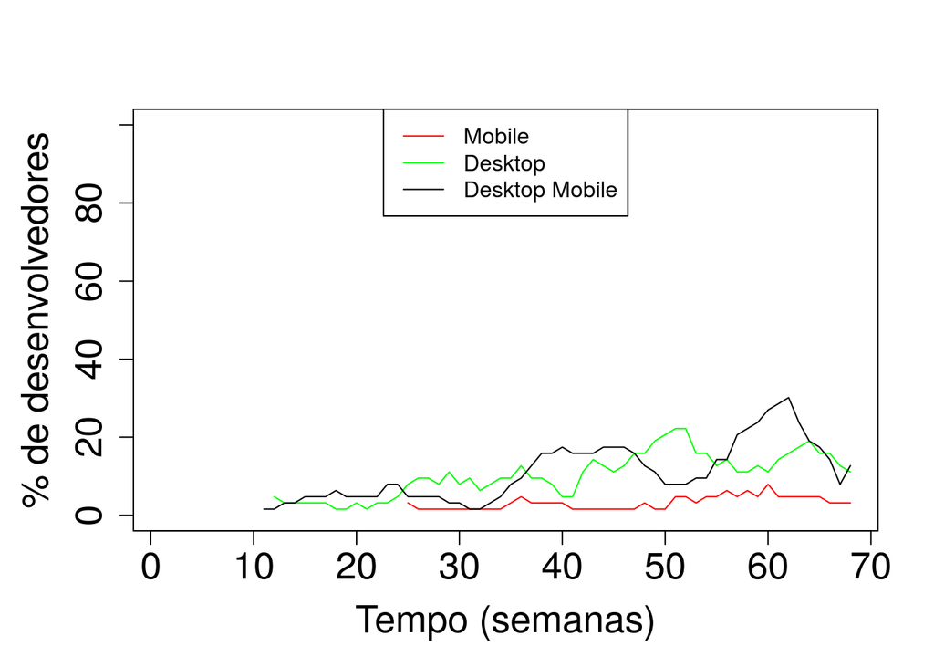

|  | mobile | desktop | mobiledesktop |
| --- | --- | --- | --- |
| twosided | 0.0001524 | 0 | 0 |
| greater | 0.0000762 | 0 | 0 |
| less | 0.9999238 | 1 | 1 |

#### Godot

0.5 [1] “

"

#### Evolução dos desenvolvedores ao longo do tempo (Desktop Mobile)

( janela 24 semanas, iteracao de 4 semanas) [1] “

"

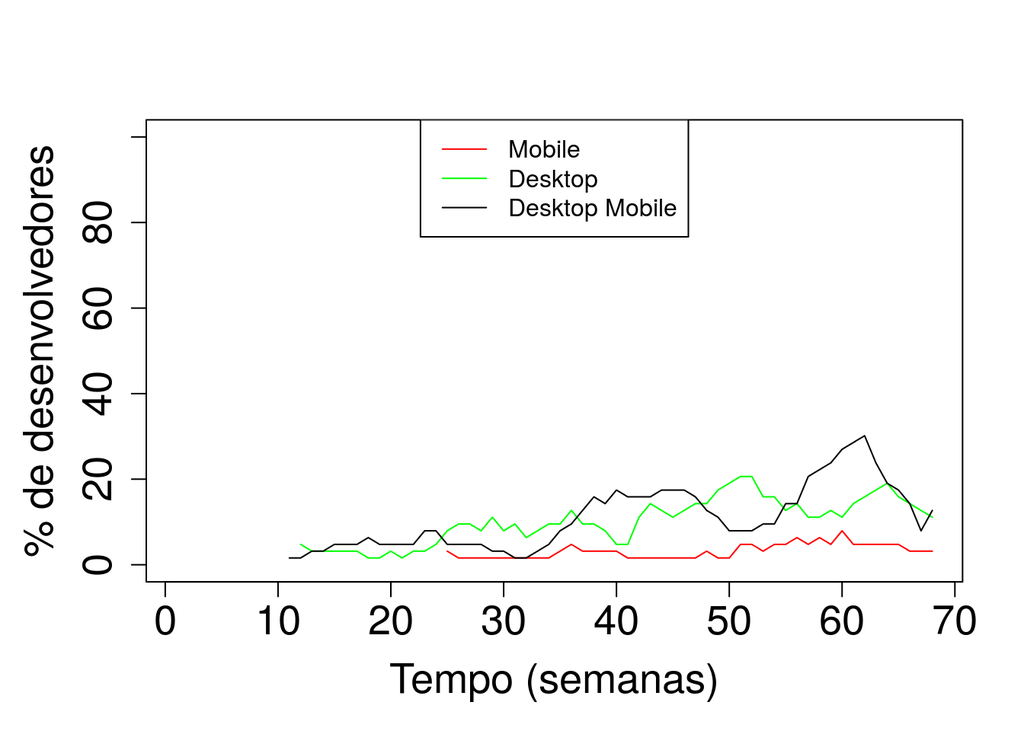

|  | mobile | desktop | mobiledesktop |
| --- | --- | --- | --- |
| twosided | 0.0001524 | 0 | 0 |
| greater | 0.0000762 | 0 | 0 |
| less | 0.9999238 | 1 | 1 |